# Figure2_20220318

# Figure 2

required libraries

```
## Setting options('download.file.method.GEOquery'='auto')
```

```
## Setting options('GEOquery.inmemory.gpl'=FALSE)
```

Load data

```r
opto_vHC <- readRDS("../data/OptoTranscriptomics_Seq1Only.vHC.SE.rds")
opto_dHC <- readRDS("../data/OptoTranscriptomics_Seq1Only.dHC.SE.rds")
DREADD_vHC <- readRDS("../data/DREADDTranscriptomics.vHC.SE.rds")
DREADD_dHC <- readRDS("../data/DREADDTranscriptomics.dHC.SE.rds")
retro_opto <- readRDS("../data/OPTO9.SE.Rds")


DREADD <- cbind(DREADD_vHC[intersect(rownames(DREADD_vHC),rownames(DREADD_dHC)),],DREADD_dHC[intersect(rownames(DREADD_vHC),rownames(DREADD_dHC)),])
DREADD <- dosvacor(DREADD, form = ~Virus + Region, form0 = ~Region)
```

```
## Number of significant surrogate variables is:  5
## Iteration (out of 5 ):1  2  3  4  5
```

```r
DREADD <- DREADD[,order(DREADD$Region,DREADD$Virus)]

opto <- cbind(opto_vHC[intersect(rownames(opto_vHC),rownames(opto_dHC)),],opto_dHC[intersect(rownames(opto_vHC),rownames(opto_dHC)),])
opto <- dosvacor(opto, form = ~Condition2 + Region, form0 = ~Region)
```

[output not shown]

[output not shown]

```
## Number of significant surrogate variables is:  5
## Iteration (out of 5 ):1  2  3  4  5
```

```r
opto <- opto[,order(opto$Region,opto$TimePoint,opto$Virus)]

mincount <- 30
Results <- list()
```

## DREADD Volcanos (Fig2B)

Volcanoplots that show the significant genes upon chemogenetic activation of LC

```r
DREADD_vHC <- dosvacor(DREADD_vHC, form = ~Virus)
```

```
## Number of significant surrogate variables is:  3
## Iteration (out of 5 ):1  2  3  4  5
```

```r
DREADD_dHC <- dosvacor(DREADD_dHC, form = ~Virus)
```

```
## Number of significant surrogate variables is:  2
## Iteration (out of 5 ):1  2  3  4  5
```

```r
y <- DGEList(counts=assays(DREADD_vHC)$counts,group = DREADD_vHC$Virus)
y <- calcNormFactors(y)
y <- estimateDisp(y)
```

```
## Using classic mode.
```

```r
y <- y[filterByExpr(y,group = DREADD_vHC$Virus, min.count = mincount),]
Results[["DREADD_vHC"]] <- exactTest(y)

y <- DGEList(counts=assays(DREADD_dHC)$counts,group = DREADD_dHC$Virus)
y <- calcNormFactors(y)
y <- estimateDisp(y)
```

```
## Using classic mode.
```

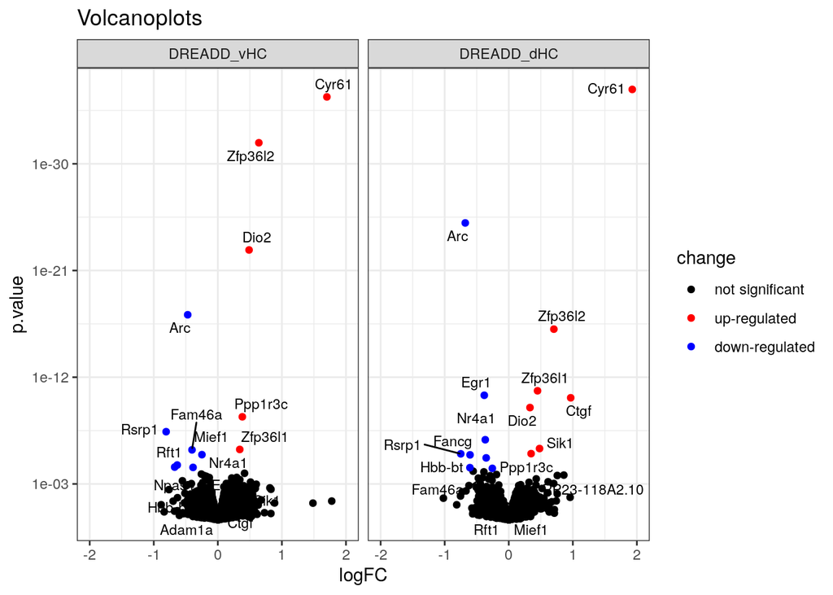

```r
y <- y[filterByExpr(y,group = DREADD_dHC$Virus, min.count = mincount),]
Results[["DREADD_dHC"]] <- exactTest(y)

sig_DREADD_vHC <- rownames(topTags(Results[["DREADD_vHC"]], n = Inf, p.value = 0.05))
sig_DREADD_dHC <- rownames(topTags(Results[["DREADD_dHC"]], n = Inf, p.value = 0.05))

Fig2B <- VolcanoPlotsEdgeR(Results[c("DREADD_vHC","DREADD_dHC")],limits = c(-2,2), lab = union(sig_DREADD_vHC,sig_DREADD_dHC))
```

## Figure 2H opto Volcanos (Fig2H)

Volcanoplots that show the significant genes upon optogenetic activation of LC at 45min and 90min (vHC only)

```r
opto_vHC <- dosvacor(opto_vHC, form = ~Condition2)
```

[output not shown]

```
## Number of significant surrogate variables is:  3
## Iteration (out of 5 ):1  2  3  4  5
```

```r
opto_dHC <- dosvacor(opto_dHC, form = ~Condition2)
```

[output not shown]

```
## Number of significant surrogate variables is:  3
## Iteration (out of 5 ):1  2  3  4  5
```

```r
opto_vHC_45min <- opto_vHC[,opto_vHC$TimePoint == "45min"]
opto_vHC_90min <- opto_vHC[,opto_vHC$TimePoint == "1h30min"]

y <- DGEList(counts=assays(opto_vHC_45min)$counts,group = opto_vHC_45min$Virus)
y <- calcNormFactors(y)
y <- estimateDisp(y)
```

```
## Using classic mode.
```

```r
y <- y[filterByExpr(y,group = opto_vHC_45min$Virus, min.count = mincount),]
Results[["opto_vHC_45min"]] <- exactTest(y)

y <- DGEList(counts=assays(opto_vHC_90min)$counts,group = opto_vHC_90min$Virus)
y <- calcNormFactors(y)
y <- estimateDisp(y)
```

```
## Using classic mode.
```

```r
y <- y[filterByExpr(y,group = opto_vHC_90min$Virus, min.count = mincount),]
Results[["opto_vHC_1h30min"]] <- exactTest(y)


opto_dHC_45min <- opto_dHC[,opto_dHC$TimePoint == "45min"]
opto_dHC_90min <- opto_dHC[,opto_dHC$TimePoint == "1h30min"]

y <- DGEList(counts=assays(opto_dHC_45min)$counts,group = opto_dHC_45min$Virus)
y <- calcNormFactors(y)
y <- estimateDisp(y)
```

```
## Using classic mode.
```

```r
y <- y[filterByExpr(y,group = opto_dHC_45min$Virus, min.count = mincount),]
Results[["opto_dHC_45min"]] <- exactTest(y)

y <- DGEList(counts=assays(opto_dHC_90min)$counts,group = opto_dHC_90min$Virus)
y <- calcNormFactors(y)
y <- estimateDisp(y)
```

```
## Using classic mode.
```

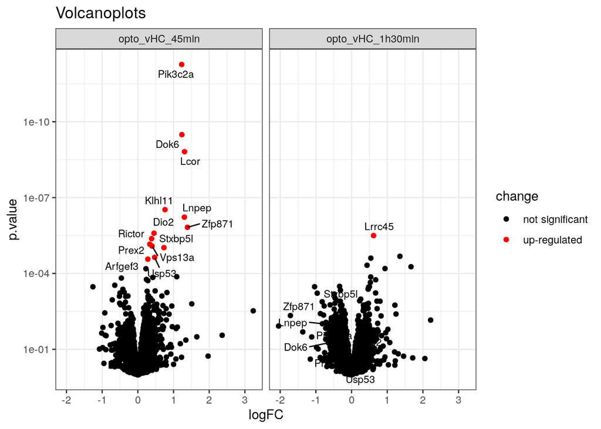

```r
y <- y[filterByExpr(y,group = opto_dHC_90min$Virus, min.count = mincount),]
Results[["opto_dHC_1h30min"]] <- exactTest(y)


sig_opto_vHC_45min <- rownames(topTags(Results[["opto_vHC_45min"]], n = Inf, p.value = 0.05))
sig_opto_vHC_90min <- rownames(topTags(Results[["opto_vHC_1h30min"]], n = Inf, p.value = 0.05))

Fig2H <- VolcanoPlotsEdgeR(Results[c("opto_vHC_45min","opto_vHC_1h30min")], lab = union(sig_opto_vHC_45min,sig_opto_vHC_90min))
```

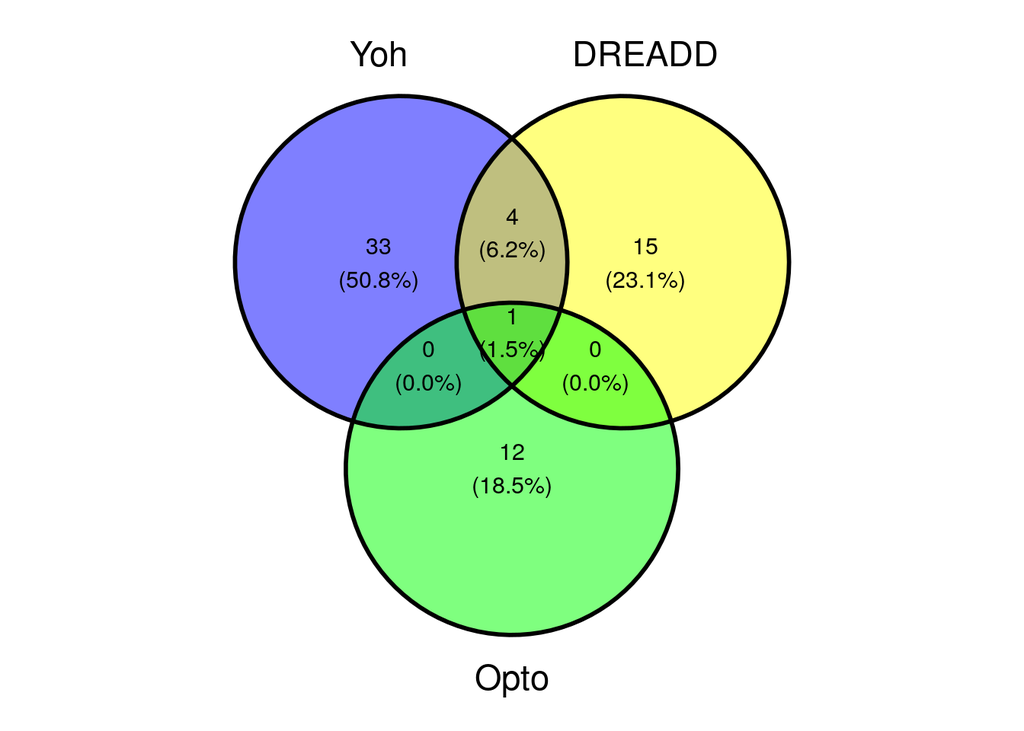

```r
#Overlap significant
STR2 <- readRDS("../final_data/STR2_Complete.SE.Rds")

YohvHC <- na.omit(rowData(STR2)$DEA.vHC_CtrlvsYohimb)
YohdHC <- na.omit(rowData(STR2)$DEA.dHC_CtrlvsYohimb)

Yoh_sig <- union(rownames(YohvHC[YohvHC$FDR < 0.05,]), rownames(YohdHC[YohdHC$FDR < 0.05,]))
DREADD_sig <- union(rownames(topTags(Results$DREADD_vHC, n = Inf, p = 0.05)), rownames(topTags(Results$DREADD_dHC, n = Inf, p = 0.05)))
opto_sig <- rownames(topTags(Results$opto_vHC_45min, n = Inf, p.value = 0.05))

x <- list(Yoh = Yoh_sig, DREADD = DREADD_sig, Opto = opto_sig)

ggvenn::ggvenn(x)
```

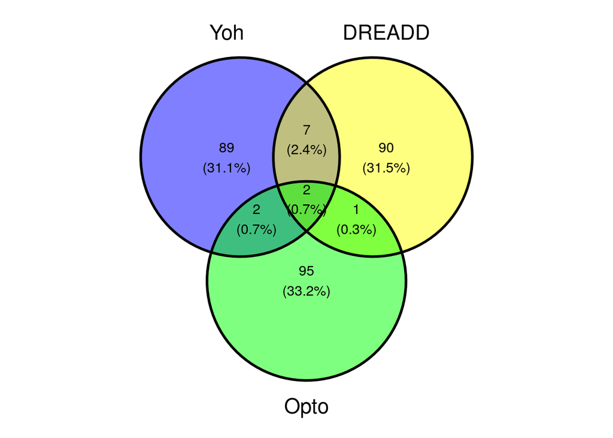

```r
#Overlap top 100
x <- list(Yoh = rownames(YohvHC[order(YohvHC$PValue),][1:100,]),
          DREADD = rownames(topTags(Results$DREADD_vHC,n = 100)),
          Opto = rownames(topTags(Results$opto_vHC_45min,n = 100)))
ggvenn::ggvenn(x)
```

## Genes with similar effect NA response across all three experiments (Fig2P)

In this analysis the three experiments (yoh, opto and dreadd) are combined again, however this time we consider the “stimulation” to be of the same type, i.e we combine all test groups and run a statistical test for it. this type of analysis will be sensitive to genes that respond very consistently to NA stimulation across all three experiments

```r
#Option A, statistical method, all combined

Yoh <- STR2[,STR2$Condition2 %in% c("Saline-Ctrl","Saline-Yohimbine")]
Yoh$Condition3 <- ifelse(Yoh$Condition == "Homecage","Control","Test")
Yoh <- Yoh[,Yoh$Region == "vHC"]
DREADD2 <- DREADD[,DREADD$Region == "vHC"]
DREADD2$Condition3 <- ifelse(DREADD2$Virus == "Control","Control","Test")
opto_vHC_45min$Condition3 <- ifelse(opto_vHC_45min$Virus == "Control","Control","Test")

m <- mergeSEs(ll = list(Yohimbne = Yoh, DREADD = DREADD2, Opto = opto_vHC_45min),commonOnly =TRUE,keepRowData = FALSE,do.scale = FALSE,use.assays = "counts")
m$Condition3 <- as.factor(m$Condition3)
m$Experiment <- as.factor(m$Experiment)

m <- dosvacor(m, form = ~Experiment + Condition3, form0 = ~Experiment)
```

```
## Number of significant surrogate variables is:  5
## Iteration (out of 5 ):1  2  3  4  5
```

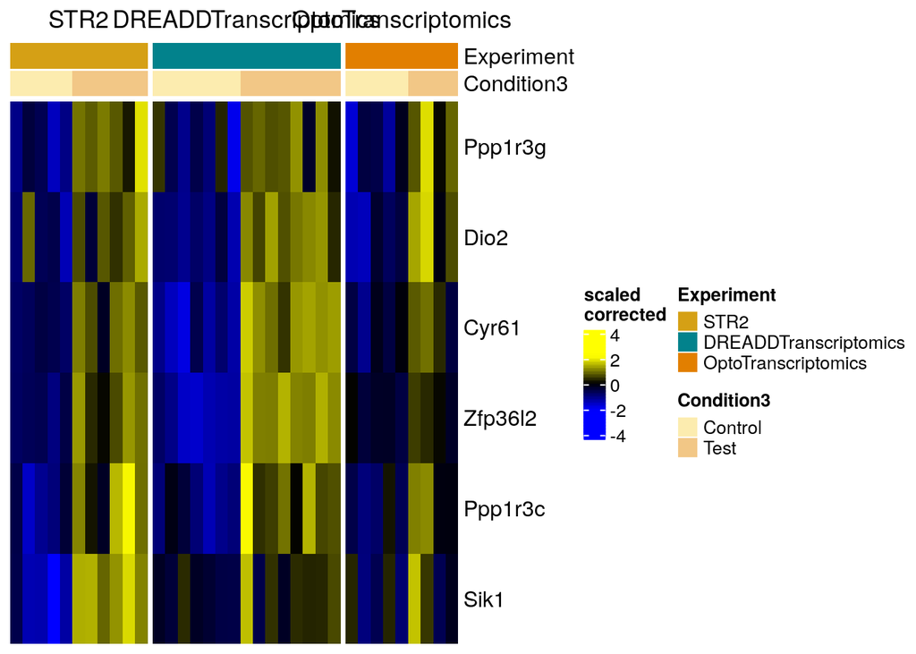

```r
m_design <- model.matrix(~m$Condition3 + m$Experiment)

y <- DGEList(counts=assays(m)$counts)
y <- calcNormFactors(y)
y <- estimateDisp(y,m_design)
#filter out genes that are low expressed
y <- y[filterByExpr(y, m_design, min.count = mincount),]
m_fit <- glmQLFit(y,m_design)

res <- glmQLFTest(m_fit, colnames(m_design)[2])

m <- m[,order(m$Condition3)]
Fig2P <- sechm(m,
      rownames(topTags(res,n = Inf, p.value = 0.05)),
      assayName = "corrected",
      do.scale = T,
      top_annotation = c("Experiment","Condition3"),
      gaps_at = c("Experiment"))
Fig2P
```

## Aggregate across datasets (FigS2X and FigS2X2)

Here we do the following to detect genes that are responsive across datasets: we see which position (by significane) a gene is in a given analysis (1st, 2nd, 3rd etc) we then sum up all these positions across the relevant analyses this gives us a ranking of genes by NA responsiveness

```r
Results2 <- readRDS("Results_stats.Rds")

datasets <- c("STR2v_StressvsPropr","STR2d_StressvsPropr","STR3_InteractionPropranolol","DREADD_vHC","DREADD_dHC","opto_vHC_45min")

#Create pvalue data frame across the selected analyses
pvals <- data.frame(Results2[[datasets[1]]]$table[,"PValue"])
rownames(pvals) <- rownames(Results2[[datasets[1]]]$table)
pvals$gene <- rownames(pvals)
for(i in datasets[-1]){
  targets <- intersect(rownames(pvals),rownames(Results2[[i]]$table))
  pvals <- pvals[targets,]
  pvals <- cbind(pvals,Results2[[i]]$table[targets,"PValue"])
}

pvals <- na.omit(pvals)
pvals$gene <- NULL

#get order of each gene in each dataset based on pvalue
ord <- apply(pvals,MARGIN = 2, FUN = function(x){
  o <- order(x)
  r <- 1:length(x)
  return(r[order(o)])
})
rownames(ord) <- rownames(pvals)
ord <- apply(ord, MARGIN = 1, FUN = sum)

#Top 20 genes
head(ord[order(ord)],20)
```

```
##         Dio2      Ppp1r3c      Ppp1r3g         Sik1      Tsc22d3      Ppp1r3d
##           50          264          321         2094         3419         3562
##           F3      Sertad1        Nr4a1        Timp3         Clk4      Rbm12b2
##         4372         5095         5171         5786         6058         6602
## RP23-15I21.8        H3f3b        Trib1         Apln         Plat         Egr4
##         6723         7101         7701         7716         7732         8013
##          Arc       Fam78a
##         8150         8202
```

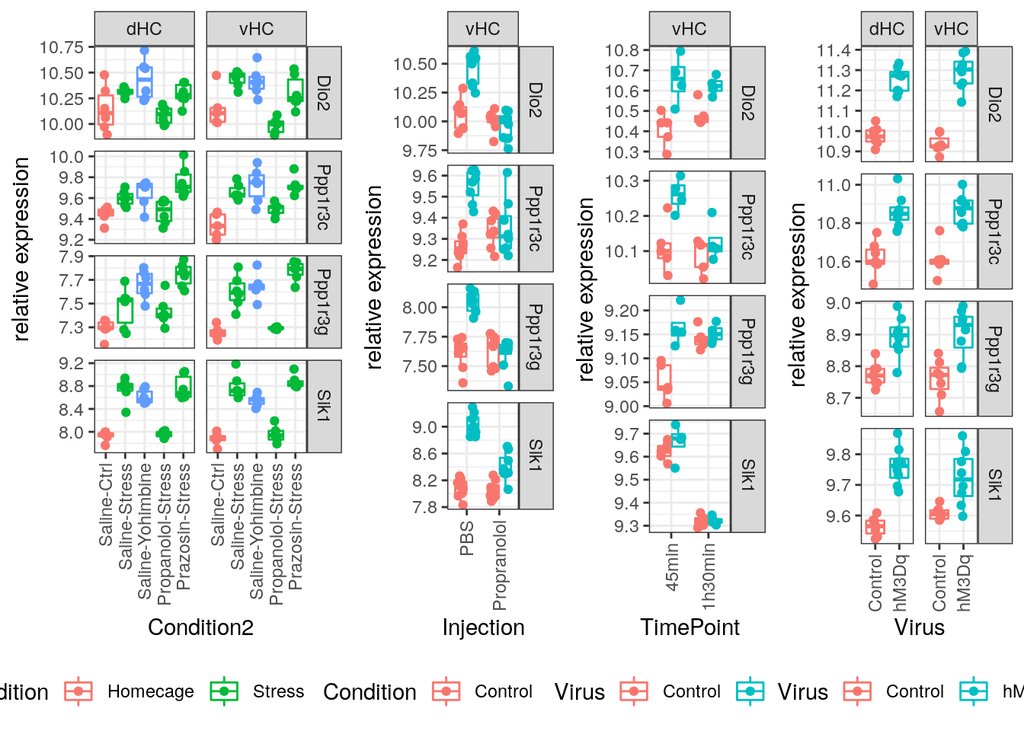

```r
#create plot of top n genes
n <- 4
n2 <- 10
t <- names(ord[order(ord)][1:n])
t2 <- names(ord[order(ord)][1:n2])

STR2 <- readRDS("../final_data/STR2_Complete.SE.Rds")
STR3 <- readRDS("../final_data/STR3_Complete.SE.Rds")
STR3 <- STR3[,STR3$Injection != "Sotalol"]

rowData(STR2) <- NULL
rowData(STR3) <- NULL

pSTR2 <- meltSE(STR2,t)
p1 <- ggplot(pSTR2,aes(Condition2, corrected, color = Condition)) +
  geom_boxplot(outlier.shape = NA) +
  geom_point(position = position_jitterdodge()) +
  facet_grid(feature~Region, scales = "free") +
  theme_bw() + theme(legend.position="bottom") +
  ylab("relative expression") +
  theme(axis.text.x = element_text(angle = 90, vjust = 0.5, hjust=1))

pSTR3 <-meltSE(STR3,t)
pSTR3 <- pSTR3[pSTR3$Injection != "Sotalol",]
p2 <- ggplot(pSTR3,aes(Injection, corrected, color = Condition)) +
  geom_boxplot(outlier.shape = NA) + geom_point(position = position_jitterdodge()) +
  facet_grid(feature~Region, scales = "free") +
  theme_bw()  +
  theme(legend.position="bottom") +
  ylab("relative expression") +
  theme(axis.text.x = element_text(angle = 90, vjust = 0.5, hjust=1))

popto <- meltSE(opto_vHC,t)
popto$TimePoint <- factor(popto$TimePoint, levels = c("45min","1h30min"))
p3 <- ggplot(popto,aes(TimePoint, corrected, color = Virus)) +
  geom_boxplot(outlier.shape = NA) +
  geom_point(position = position_jitterdodge()) +
  facet_grid(feature~Region, scales = "free") +
  theme_bw()  + theme(legend.position="bottom") +
  ylab("relative expression")+
  theme(axis.text.x = element_text(angle = 90, vjust = 0.5, hjust=1))

pDREADD <- meltSE(DREADD,t)
p4 <- ggplot(pDREADD,aes(Virus, corrected, color = Virus)) +
  geom_boxplot(outlier.shape = NA) +
  geom_point(position = position_jitterdodge()) +
  facet_grid(feature~Region, scales = "free") +
  theme_bw()  + theme(legend.position="bottom") +
  ylab("relative expression")+
  theme(axis.text.x = element_text(angle = 90, vjust = 0.5, hjust=1))

FigS2X <- plot_grid(p1,p2,p3,p4,nrow = 1,rel_widths = c(1,0.6,0.6,0.7))
FigS2X
```

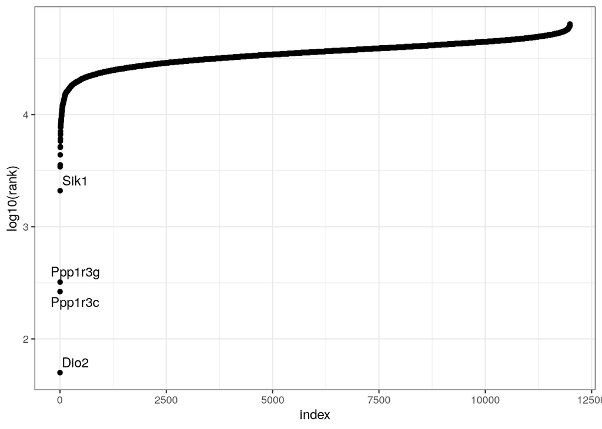

```r
#plot genes by log rank

df_NAgenes <- data.frame(rank = ord[order(ord)], index = 1:length(ord))
df_NAgenes$lab <- rep(NA,nrow(df_NAgenes))
df_NAgenes$lab[1:n] <- t
FigS2X2 <- ggplot(df_NAgenes,aes(index, log10(rank), label = lab)) + geom_point() + theme_bw() + geom_text_repel()
FigS2X2
```

```r
saveRDS(df_NAgenes,"../final_data/NAgenes.Rds")
```

## NA responsive genes in retrograde opto (Fig2L, will go to Figure 3!)

Here we select the top genes from the NA responsivenes analysis and analyse only these genes in the retro opto dataset

```r
retro_opto_CHR2pvsn <- retro_opto[,retro_opto$Group != "HC"]
retro_opto_CHR2pvsn$Group <- droplevels(retro_opto_CHR2pvsn$Group)
retro_opto_CHR2pvsn <- dosvacor(retro_opto_CHR2pvsn, form = ~Group)
```

```
## Number of significant surrogate variables is:  1
## Iteration (out of 5 ):1  2  3  4  5
```

```r
y <- DGEList(counts=assays(retro_opto_CHR2pvsn)$counts,group = retro_opto_CHR2pvsn$Group)
y <- calcNormFactors(y)
y <- estimateDisp(y)
```

```
## Using classic mode.
```

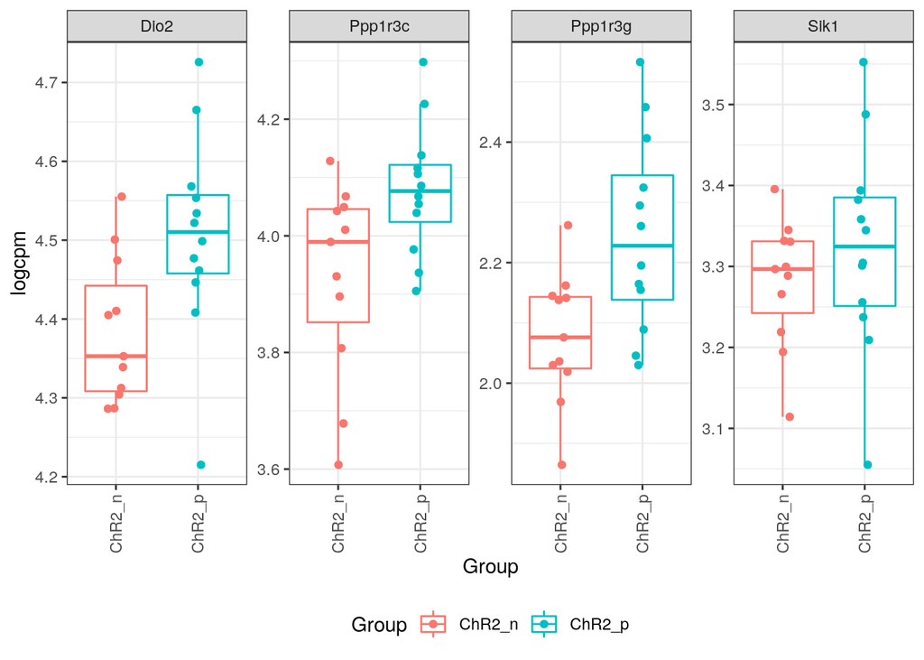

```r
y <- y[filterByExpr(y,group = retro_opto_CHR2pvsn$Group, min.count = mincount),]
Results[["retro_opto_CHR2pvsn"]] <- exactTest(y)

pretro_opto <- meltSE(retro_opto_CHR2pvsn,t)

stats <- Results[["retro_opto_CHR2pvsn"]]$table[t,]
stats$FDR <- p.adjust(stats$PValue, method = "fdr")

Fig2L <- ggplot(pretro_opto,aes(Group, logcpm, color = Group)) +
  geom_boxplot(outlier.shape = NA) +
  geom_point(position = position_jitterdodge()) +
  facet_wrap(~feature, scales = "free", nrow = 1) +
  theme_bw()  + theme(legend.position="bottom") +
  ylab("logcpm")+
  theme(axis.text.x = element_text(angle = 90, vjust = 0.5, hjust=1))

Fig2L
```

```r
stats
```

```
##              logFC   logCPM      PValue        FDR
## Dio2    0.18353702 6.413896 0.009883573 0.01636552
## Ppp1r3c 0.21220807 5.774628 0.012274138 0.01636552
## Ppp1r3g 0.28356462 2.988492 0.004763314 0.01636552
## Sik1    0.07287063 4.726277 0.315040140 0.31504014
```

## NA turnover (MHPG/NA) vs Dio2 expression (Fig2M)

Here we correlate the MHPG/NA vs Dio2 expression in the retro opto experiment. we run a statistical analysis for correlation one time across all samples, and one time also across the Chr2 positive virus samples only. both are significant

```r
meta <- read.xlsx("../data/Opto9_HPLC_RH-dHC_R.xlsx",sheetIndex = 1)[1:34,]


assign <- match(colnames(retro_opto_CHR2pvsn), meta$Sample)
retro_opto_CHR2pvsn$MHPG <- meta[assign,"MHPG"]
retro_opto_CHR2pvsn$NE <- meta[assign,"NE"]
retro_opto_CHR2pvsn$ratioMHPGvNE <- retro_opto_CHR2pvsn$MHPG / retro_opto_CHR2pvsn$NE

#linear correaltion across all samples
pdat <- meltSE(retro_opto_CHR2pvsn,"Dio2")
mod <- lm(pdat$logcpm ~ pdat$ratioMHPGvNE)
summary(mod)
```

```
##
## Call:
## lm(formula = pdat$logcpm ~ pdat$ratioMHPGvNE)
##
## Residuals:
##       Min        1Q    Median        3Q       Max
## -0.202264 -0.067255  0.001906  0.063101  0.160148
##
## Coefficients:
##                   Estimate Std. Error t value Pr(>|t|)
## (Intercept)         4.0921     0.0915  44.721  < 2e-16 ***
## pdat$ratioMHPGvNE   2.2900     0.5741   3.989 0.000667 ***
## ---
## Signif. codes:  0 '***' 0.001 '**' 0.01 '*' 0.05 '.' 0.1 ' ' 1
##
## Residual standard error: 0.09774 on 21 degrees of freedom
## Multiple R-squared:  0.4311, Adjusted R-squared:  0.404
## F-statistic: 15.91 on 1 and 21 DF,  p-value: 0.0006669
```

```r
#linear correaltion within the ChR2_p group only
pdat_p <- pdat[pdat$Group == "ChR2_p",]
mod <- lm(pdat_p$logcpm ~ pdat_p$ratioMHPGvNE)
summary(mod)
```

```
##
## Call:
## lm(formula = pdat_p$logcpm ~ pdat_p$ratioMHPGvNE)
##
## Residuals:
##      Min       1Q   Median       3Q      Max
## -0.19040 -0.08165  0.03329  0.05659  0.14233
##
## Coefficients:
##                     Estimate Std. Error t value Pr(>|t|)
## (Intercept)           4.0392     0.2068  19.530 2.71e-09 ***
## pdat_p$ratioMHPGvNE   2.5794     1.1286   2.285   0.0454 *
## ---
## Signif. codes:  0 '***' 0.001 '**' 0.01 '*' 0.05 '.' 0.1 ' ' 1
##
## Residual standard error: 0.1092 on 10 degrees of freedom
## Multiple R-squared:  0.3431, Adjusted R-squared:  0.2774
## F-statistic: 5.223 on 1 and 10 DF,  p-value: 0.04536
```

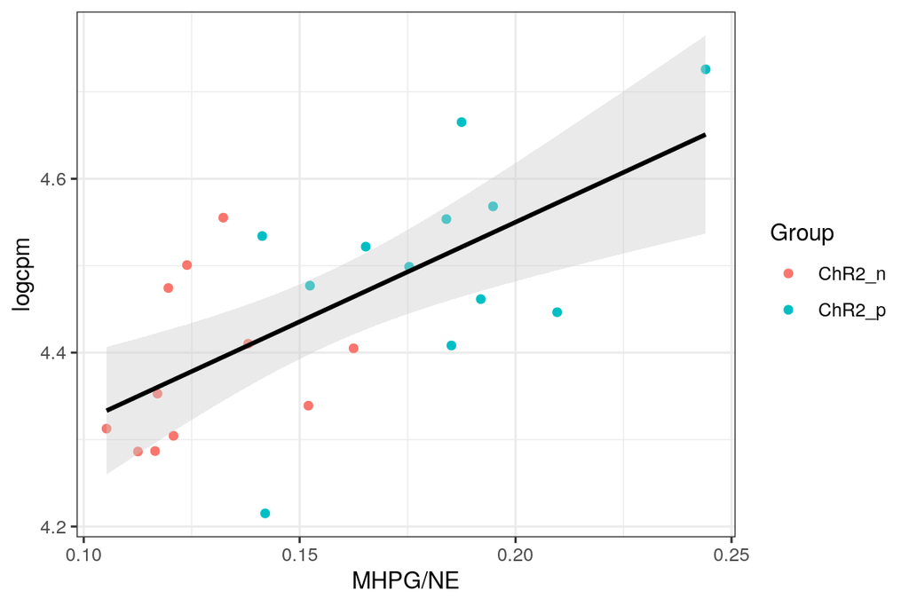

```r
Fig2M <- ggplot(pdat, aes(MHPG/NE,logcpm)) + geom_point(aes(MHPG/NE,logcpm, color = Group)) + theme_bw() + geom_smooth(method = "lm", color = "black", fill = "grey80")
Fig2M
```

We visualize the response strength of the top NA genes in the retro and optofmri data and produce statistical results for these selected genes (subset for reduced multiple testing correction)

```r
LCopto <- readRDS("../data/LCOptoFmri.SE.rds")
LCopto <- LCopto[,LCopto$Tissue == "R-vHC"]
LCopto <- dosvacor(LCopto,form = ~Group + Sex, form0 = ~Sex)
```

```
## Number of significant surrogate variables is:  2
## Iteration (out of 5 ):1  2  3  4  5
```

```r
design <- model.matrix(~LCopto$Group + LCopto$SV1 + LCopto$SV2)

y <- DGEList(counts=assays(LCopto)$counts)
y <- calcNormFactors(y)
y <- estimateDisp(y,design)
#filter out genes that are low expressed
y <- y[filterByExpr(y, design),]

fit <- glmQLFit(y,design)

Results[["vHC.FullModel"]] <- glmQLFTest(fit, colnames(design)[2:4])
Results[["vHC.FullModel"]]$table$meanLogFC <- apply(Results[["vHC.FullModel"]]$table,1,FUN = function(x){mean(x[1:3])})
Results[["vHC.FullModel"]]$table$logFC <- apply(Results[["vHC.FullModel"]]$table,1,FUN = function(x){mean(x[1:3])})
Results[["vHC.3Hz"]] <- glmQLFTest(fit, colnames(design)[2])
Results[["vHC.5Hz"]] <- glmQLFTest(fit, colnames(design)[3])
Results[["vHC.15Hz"]] <- glmQLFTest(fit, colnames(design)[4])

stats <- Results[["retro_opto_CHR2pvsn"]]$table[t2,]
stats$FDR <- p.adjust(stats$PValue, method = "fdr")

pdat <- data.frame(gene = t2,
                   logFC.vHC.retro =   Results[["retro_opto_CHR2pvsn"]]$table[t2,"logFC"],
                   logFC.vHC3Hz = Results[["vHC.FullModel"]]$table[t2,"logFC.LCopto.Group3Hz"],
                   logFC.vHC5Hz = Results[["vHC.FullModel"]]$table[t2,"logFC.LCopto.Group5Hz"],
                   logFC.vHC15Hz = Results[["vHC.FullModel"]]$table[t2,"logFC.LCopto.Group15Hz"])

pdat$index <- NULL
pdat[,c("logFC")] <- NULL
radial.df <- tidyr::pivot_longer(pdat,cols = -1)
radial.df$direction = ifelse(radial.df$value >= 0, "up-regulated", "down-regulated")
radial.df$value <- abs(radial.df$value)

radial.df$name <- factor(radial.df$name, levels = c("logFC.vHC.retro","logFC.vHC3Hz","logFC.vHC5Hz","logFC.vHC15Hz"))

Fig2Q <- ggplot(radial.df, aes(x=gene, y=sqrt(value), fill=gene, color = direction)) +
    geom_bar(stat='identity') + facet_wrap(~name, nrow = 1) + coord_polar() + scale_color_manual(values= c("red","black")) + theme_bw() + ggtitle("top 10 NA genes in vHC and dHC using different stimulation frequencies")

#stats, different stimulations
topTags(Results[["vHC.FullModel"]][t2,])
```

```
## Coefficient:  LCopto$Group3Hz LCopto$Group5Hz LCopto$Group15Hz
##         logFC.LCopto.Group3Hz logFC.LCopto.Group5Hz logFC.LCopto.Group15Hz
## Ppp1r3c            0.36999035           0.372553817             0.31789162
## Dio2               0.27617619           0.395628499             0.26908988
## Ppp1r3d            0.26046225           0.084033557             0.17260574
## Sertad1            0.20623677          -0.004422874             0.09532448
## F3                -0.14952996          -0.137174676            -0.14667318
## Sik1               0.16554242           0.243185263             0.21222094
## Nr4a1              0.11056095           0.161605656             0.11887384
## Timp3              0.03520771           0.185645283             0.03148772
## Ppp1r3g            0.06694708           0.196719075             0.23650100
## Tsc22d3           -0.15628705          -0.030820870            -0.10444660
##           logCPM          F       PValue   meanLogFC       logFC          FDR
## Ppp1r3c 5.940471 17.6540778 2.451023e-06  0.35347860  0.35347860 2.451023e-05
## Dio2    6.342405  9.6948629 2.070916e-04  0.31363152  0.31363152 1.035458e-03
## Ppp1r3d 3.318129  3.7316093 2.428992e-02  0.17236718  0.17236718 8.096638e-02
## Sertad1 3.390255  3.0870394 4.564274e-02  0.09904613  0.09904613 1.067394e-01
## F3      5.254334  2.9312283 5.336972e-02 -0.14445927 -0.14445927 1.067394e-01
## Sik1    4.803867  2.4360328 8.860214e-02  0.20698287  0.20698287 1.476702e-01
## Nr4a1   7.019252  1.9180280 1.527941e-01  0.13034682  0.13034682 2.182773e-01
## Timp3   6.965930  1.2568239 3.107685e-01  0.08411357  0.08411357 3.884606e-01
## Ppp1r3g 3.414643  1.0197972 4.007834e-01  0.16672238  0.16672238 4.453149e-01
## Tsc22d3 6.293539  0.5309312 6.652711e-01 -0.09718484 -0.09718484 6.652711e-01
```

## Show Final Figures

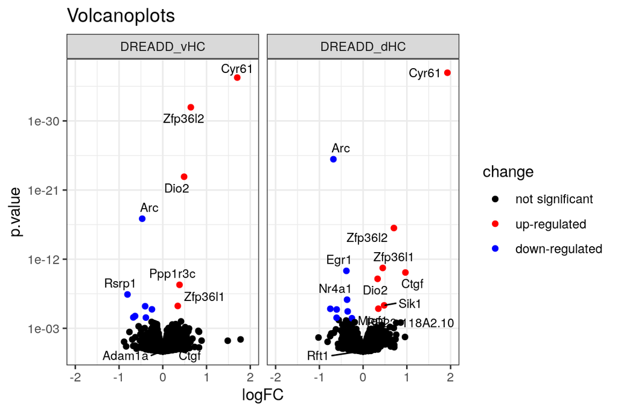

```r
print(Fig2B)
```

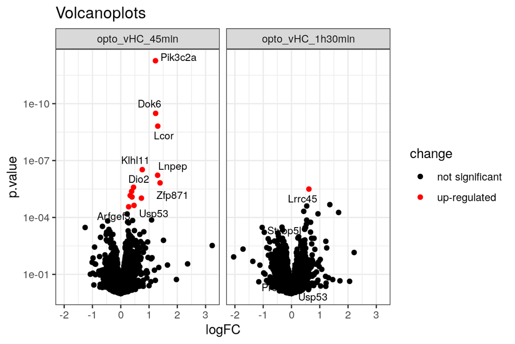

```r
print(Fig2H)
```

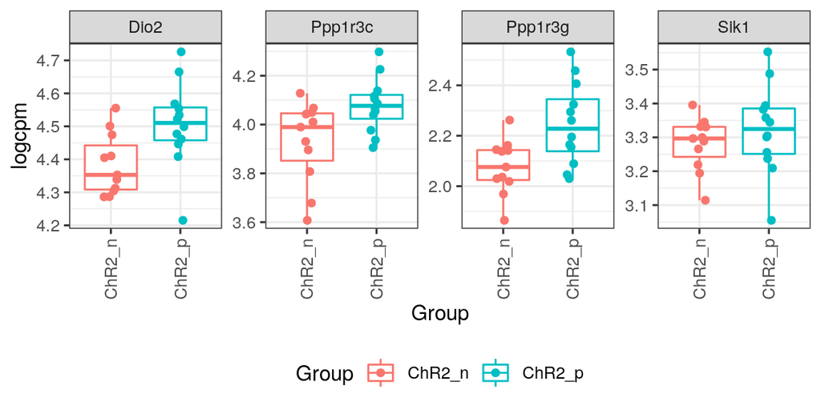

```r
print(Fig2L)
```

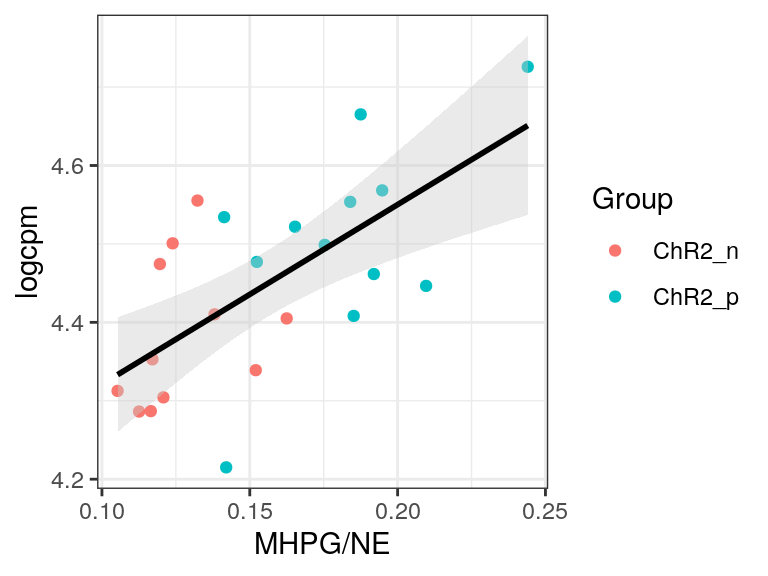

```r
print(Fig2M)
```

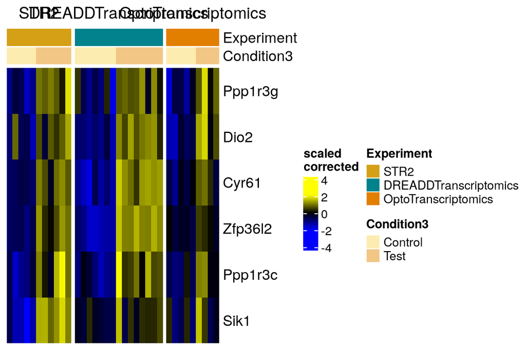

```r
print(Fig2P)
```

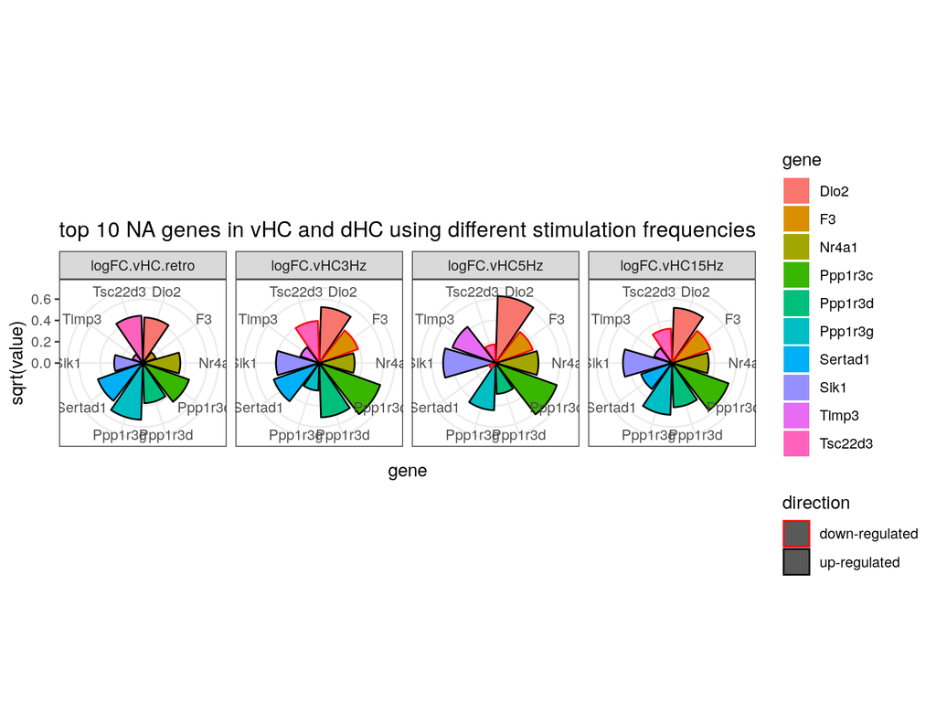

```r
print(Fig2Q)
```

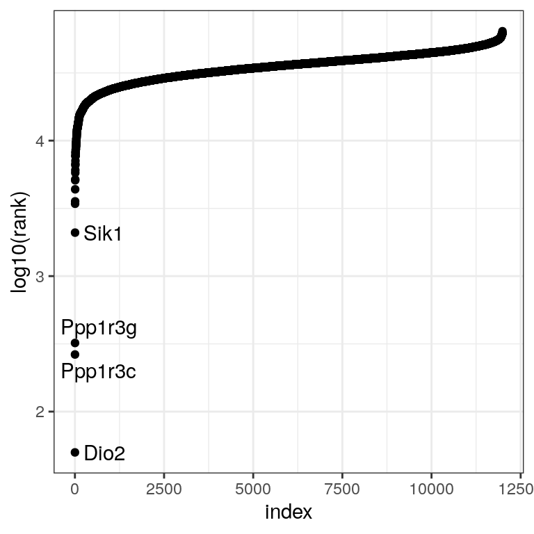

```r
print(FigS2X2)
```

## Export Figures

```r
pdf(file = "../Figures/Fig2B.pdf", width = 6, height = 4)
print(Fig2B)
dev.off()
```

```r
pdf(file = "../Figures/Fig2H.pdf", width = 6, height = 4)
print(Fig2H)
dev.off()
```

```r
pdf(file = "../Figures/Fig2L.pdf", width = 6, height = 3)
print(Fig2L)
dev.off()
```

```r
pdf(file = "../Figures/Fig2M.pdf", width = 4, height = 3)
print(Fig2M)
dev.off()
```

```r
pdf(file = "../Figures/Fig2Q.pdf", width = 6, height = 8)
print(Fig2Q)
dev.off()
```

```r
pdf(file = "../Figures/FigS2X.pdf", width = 10, height = 8)
print(FigS2X)
dev.off()
```

```r
pdf(file = "../Figures/FigS2X2.pdf", width = 4, height = 4)
print(FigS2X2)
dev.off()
```

## Create final data frames (containing corrected expression and Results data as single SE file)

```r
for(i in names(Results)){
  Results[[i]]$table$FDR <- p.adjust(Results[[i]]$table$PValue, method = "fdr")
}

rowData(opto_vHC)$DEA.vHC_45min <- Results$opto_vHC_45min$table[rownames(opto_vHC),]
attr(rowData(opto_vHC)$DEA.vHC_45min, "description") <- "two group analysis of ChR2 vs control virus analysis after 45min"

rowData(opto_vHC)$DEA.vHC_1h30min <- Results$opto_vHC_1h30min$table[rownames(opto_vHC),]
attr(rowData(opto_vHC)$DEA.vHC_1h30min, "description") <- "two group analysis of ChR2 vs control virus analysis after 1h30min"

metadata(opto_vHC)$default_view <- list(assay = "corrected", groupvar = "TimePoint", colvar = "Virus")
metadata(opto_vHC)$description <- "In this experiment the vHC transcriptome of animals in which LC was activated optogenetically 45min or 1h30min prior to sacrifice is tested"

saveRDS(opto_vHC, "../final_data/Opto_Complete.Rds")

rowData(DREADD)$DEA.vHC <- Results$DREADD_vHC$table[rownames(DREADD),]
attr(rowData(DREADD)$DEA.vHC, "description") <- "two group analysis of hM3Dq vs control virus analysis after 45min in vHC"

rowData(DREADD)$DEA.dHC <- Results$DREADD_dHC$table[rownames(DREADD),]
attr(rowData(DREADD)$DEA.dHC, "description") <- "two group analysis of hM3Dq vs control virus analysis after 45min in dHC"

metadata(DREADD)$default_view <- list(assay = "corrected", gridvar = "Region", groupvar = "Virus", colvar = "Virus")
metadata(DREADD)$description <- "In this experiment the vHC and dHC transcriptome of animals in which LC was activated chemogenetically 45min prior to sacrifice is tested"

saveRDS(DREADD, "../final_data/DREADD_Complete.Rds")

rowData(retro_opto_CHR2pvsn)$DEA.ChR2vsControl <- Results$retro_opto_CHR2pvsn$table[rownames(retro_opto_CHR2pvsn),]
attr(rowData(retro_opto_CHR2pvsn)$DEA.ChR2vsControl, "description") <- "two group analysis of ChR2 vs control retro virus analysis after 45min in vHC"

metadata(retro_opto_CHR2pvsn)$default_view <- list(assay = "corrected", groupvar = "Group", colvar = "Group")
metadata(retro_opto_CHR2pvsn)$description <- "In this experiment the vHC transcriptome of animals in which LC neurons that project to the hippocampus were activated optogenetically 45min prior to sacrifice is assessed"

saveRDS(retro_opto_CHR2pvsn, "../final_data/RetroOpto_Complete.Rds")
```